# Functional Neural Network for Scalar-on-Function Regression

In this notebook, we implement and evaluate a Functional Neural Network (FNN) for predicting fat values from spectroscopic data. The FNN is built roughly following the framework outlined in Thind et al. (2023). See [FuncNN GitHub Repo](https://github.com/b-thi/FuncNN) for the authors’ own library for their experiments. The functional predictors are first preprocessed (centered and scaled) and then smoothed using a basis expansion. The network is then fitted with a chosen set of hidden layers and activation functions. In the following sections, we compare the performance of the FNN for different smoothing (penalty) parameters and also compare it with a functional linear model (i.e. no hidden layers).

## Loading Dependencies and Data

```r
# dependencies
packages <- c(
  "fda", "torch", "dplyr", "tidyr", "ggplot2"
)
installed <- packages %in% rownames(installed.packages())
if (any(!installed)) {
  install.packages(packages[!installed])
}

library(tidyr)
library(dplyr)
library(ggplot2)
library(fda)
library(torch)
source("SoFNN.R")
```

We load the `Fatspectrum` and `Fatvalues` data from the `{fds}` package. The spectroscopic data (X) and corresponding fat values (y) are reshaped into a tidy format for visualization. The first plot shows the spectrums for each subject over the observed wavelengths, colored by their fat value.

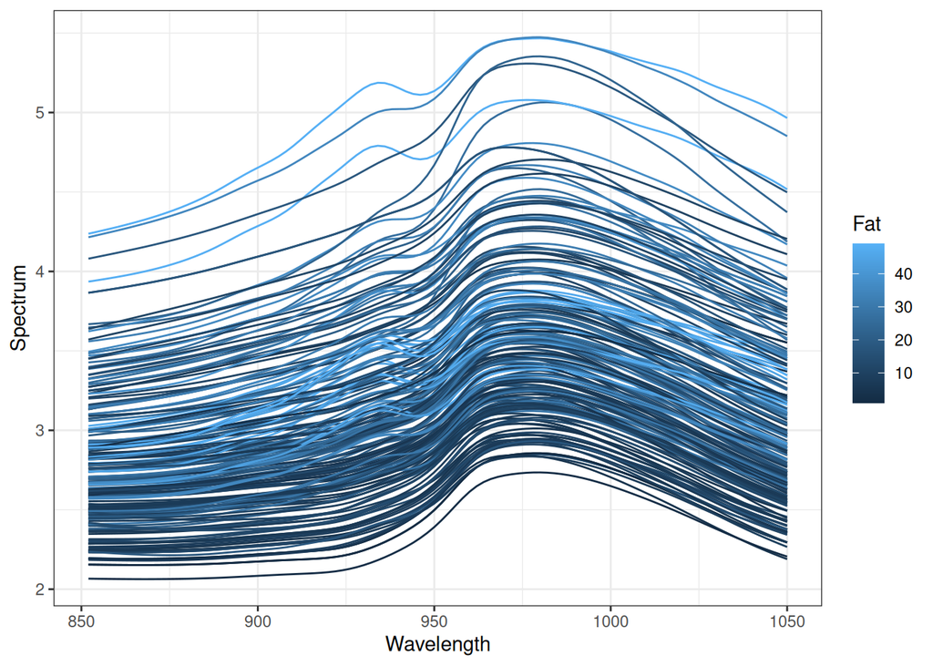

```r
data(Fatspectrum, package = "fds")
data(Fatvalues, package = "fds")

tvals = Fatspectrum$x
names(tvals) = paste0("t", seq_along(tvals))
X = t(Fatspectrum$y)
y = Fatvalues

colnames(X) = paste0("t", seq_along(tvals))
tidy_data = cbind(subj=1:nrow(X), X, Fat=y) |>
  as_tibble() |>
  pivot_longer(
    cols=paste0("t", seq_along(tvals)),
    names_to = "tid",
    values_to = "Spectrum"
  ) |>
  mutate(Wavelength = tvals[tid])

ggplot(tidy_data, aes(x = Wavelength, y = Spectrum)) +
  geom_line(aes(color=Fat, group=subj)) +
  theme_bw()
```

## Fitting the FNN

**Case 1**: Low Smoothing (lambda = 1e-7)

With a small lambda, little penalty is imposed. This configuration may result in a functional weight that fits the training data closely but could have larger variations.

```r
sofnn = fit.sofnn(
  y, X, tgrid = tvals, lambda = 1e-7, nbasis = 11,
  hidden_sizes = c(16), act_func = "relu", max_epoch = 1000,
  verbose = FALSE)

cat(
  "Initial loss:", sofnn$loss_history[1], "\n",
  "Final loss:", tail(sofnn$loss_history, 1), "\n"
)
```

```
## Initial loss: 0.9595715
##  Final loss: 0.02165333
```

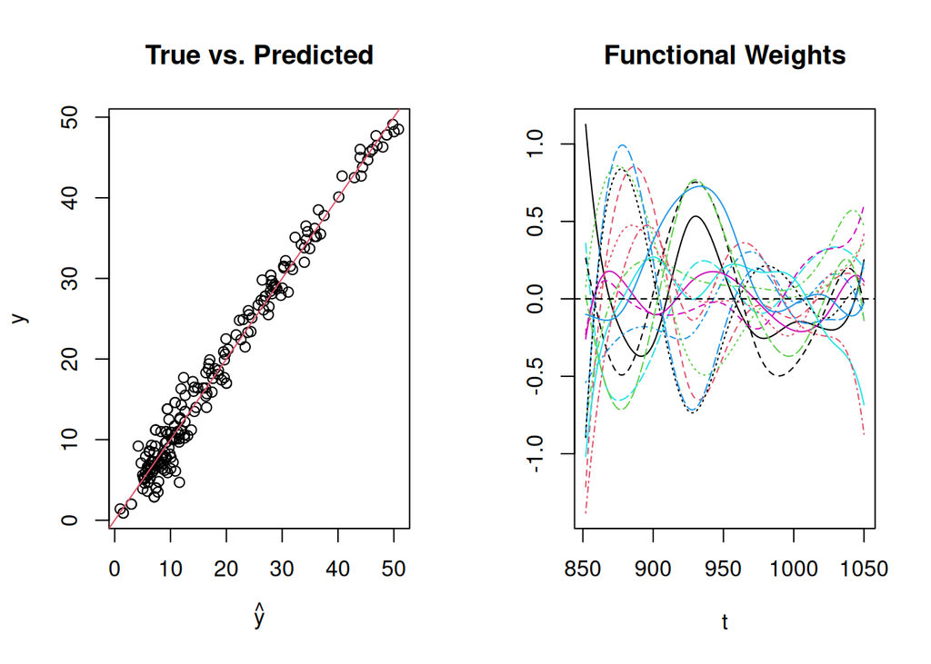

```
## [1] "done"
```

```r
par(mfrow=c(1,2))
predict(sofnn, X=X, tgrid=tvals) |>
  plot(y, main="True vs. Predicted", xlab=expression(hat(y)), ylab="y")
abline(coef=c(0,1), col=2)
plot(sofnn$func_weights[[1]], xlab="t", ylab="", main="Functional Weights")
```

```r
par(mfrow=c(1,1))
```

**Case 2**: High Smoothing (lambda = 1e3)

A very large lambda imposes a strong penalty, forcing the estimated weight function to be very smooth, which might oversmooth the relationship between the predictors and response.

```r
sofnn = fit.sofnn(
  y, X, tgrid = tvals, lambda = 1e3, nbasis = 11,
  hidden_sizes = c(16), act_func = "relu", max_epoch = 1000,
  verbose = FALSE)

cat(
  "Initial loss:", sofnn$loss_history[1], "\n",
  "Final loss:", tail(sofnn$loss_history, 1), "\n"
)
```

```
## Initial loss: 4.063223
##  Final loss: 0.112314
```

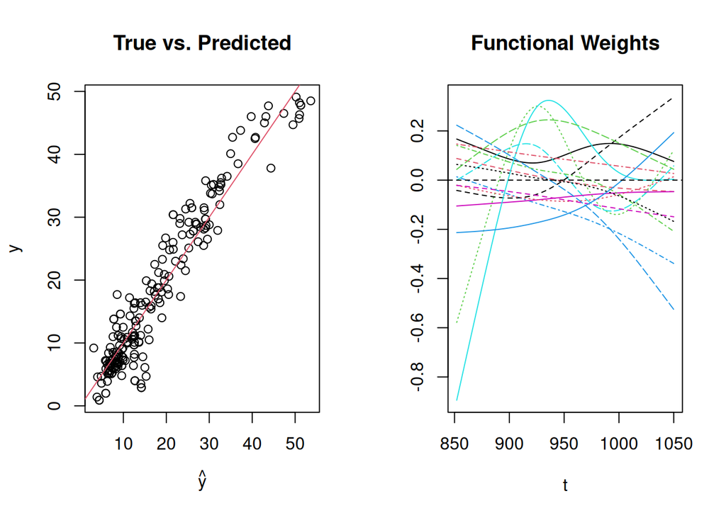

```
## [1] "done"
```

```r
par(mfrow=c(1,2))
predict(sofnn, X=X, tgrid=tvals) |>
  plot(y, main="True vs. Predicted", xlab=expression(hat(y)), ylab="y")
abline(coef=c(0,1), col=2)
plot(sofnn$func_weights[[1]], xlab="t", ylab="", main="Functional Weights")
```

```r
par(mfrow=c(1,1))
```

**Case 3**: Functional Linear Model (no hidden layers)

By setting `hidden_sizes` to an empty vector, the model is reduced to a functional linear model. This serves as a baseline for comparison against the nonlinear FNN.

```r
sofnn = fit.sofnn(
  y, X, tgrid = tvals, lambda = 1e-3, nbasis = 11,
  hidden_sizes = c(), act_func = "relu", max_epoch = 1000,
  verbose = FALSE)

cat(
  "Initial loss:", sofnn$loss_history[1], "\n",
  "Final loss:", tail(sofnn$loss_history, 1), "\n"
)
```

```
## Initial loss: 1.041318
##  Final loss: 0.138107
```

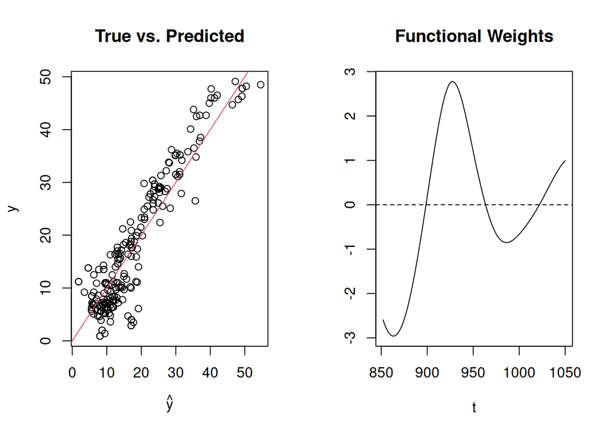

```
## [1] "done"
```

```r
par(mfrow=c(1,2))
predict(sofnn, X=X, tgrid=tvals) |>
  plot(y, main="True vs. Predicted", xlab=expression(hat(y)), ylab="y")
abline(coef=c(0,1), col=2)
plot(sofnn$func_weights[[1]], xlab="t", ylab="", main="Functional Weights")
```

```r
par(mfrow=c(1,1))
```